# Anexo Lista 1 - Análise de Dados Categorizados

Textbook: Agresti (2007) - Introduction to Categorical Data Analysis

Allan Vieira 14/0128492

May 8, 2018

### Exercício 9 (3.5)

*For Table 3.1 on snoring and heart disease, re-fit the linear probability model for the logistic regression model using the scores (i) (0, 2, 4, 6), (ii) (0, 1, 2, 3), (iii) (1, 2, 3, 4). Compare the model parameter estimates under the three choices. Compare the fitted values. What can you conclude about the effect of transformations of scores (called linear) that preserve relative sizes of spacings between scores?*

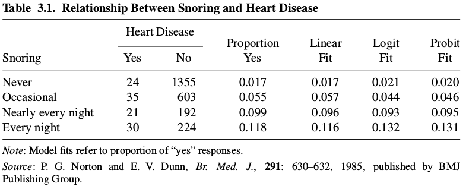

##### **i) escores (0,2,4,6)**

```r
dados <- c(24, 35, 21, 30, 1355, 603, 192, 224)
d <- matrix(dados, ncol=2)

# i) scores: {0,2,4,6}
snoring1<-c(0,2,4,6) # snoring eh uma unica variavel!!!
colnames(d) <- c("yes", "no")
logit_model1 <-glm(d~snoring1,
                family=binomial(link=logit))

# logit_model1
# logit_model1$fitted.values
summary(logit_model1)
```

```
##
## Call:
## glm(formula = d ~ snoring1, family = binomial(link = logit))
##
## Deviance Residuals:
##      1       2       3       4
## -1.297   1.526   1.074  -1.037
##
## Coefficients:
##             Estimate Std. Error z value Pr(>|z|)
## (Intercept) -3.77738    0.15571 -24.260  < 2e-16 ***
## snoring1     0.32726    0.04126   7.931 2.18e-15 ***
## ---
## Signif. codes:  0 '***' 0.001 '**' 0.01 '*' 0.05 '.' 0.1 ' ' 1
##
## (Dispersion parameter for binomial family taken to be 1)
##
##     Null deviance: 65.9045  on 3  degrees of freedom
## Residual deviance:  6.2398  on 2  degrees of freedom
## AIC: 30.492
##
## Number of Fisher Scoring iterations: 4
```

#### **ii) escores (0,1,2,3)**

```r
# ii) scores: {0,1,2,3} (linear)

snoring2<-c(0,1,2,3)
colnames(d) <- c("yes", "no")
logit_model2 <-glm(d~snoring2,
                   family=binomial(link=logit))
# logit_model2
# logit_model2$fitted.values
summary(logit_model2)
```

```
##
## Call:
## glm(formula = d ~ snoring2, family = binomial(link = logit))
##
## Deviance Residuals:
##      1       2       3       4
## -1.297   1.526   1.074  -1.037
##
## Coefficients:
##             Estimate Std. Error z value Pr(>|z|)
## (Intercept) -3.77738    0.15571 -24.260  < 2e-16 ***
## snoring2     0.65453    0.08253   7.931 2.18e-15 ***
## ---
## Signif. codes:  0 '***' 0.001 '**' 0.01 '*' 0.05 '.' 0.1 ' ' 1
##
## (Dispersion parameter for binomial family taken to be 1)
##
##     Null deviance: 65.9045  on 3  degrees of freedom
## Residual deviance:  6.2398  on 2  degrees of freedom
## AIC: 30.492
##
## Number of Fisher Scoring iterations: 4
```

#### **iii) escores (1,2,3,4)**

```r
# iii) scores: {1,2,3,4} (linear)
snoring3<-c(1,2,3,4)
colnames(d) <- c("yes", "no")
logit_model3 <-glm(d~snoring3,
                   family=binomial(link=logit))

# summary(logit_model3)
# logit_model3$fitted.values
summary(logit_model3)$coefficients
```

```
##               Estimate Std. Error    z value     Pr(>|z|)
## (Intercept) -4.4319052 0.22557252 -19.647363 6.089575e-86
## snoring3     0.6545296 0.08252999   7.930809 2.177228e-15
```

#### **iv) comparações coeficientes**

```r
df_coef <- data.frame(rbind(
logit_model1$coefficients,
logit_model2$coefficients,
logit_model3$coefficients
))

rownames(df_coef) <- c("modelo1 scores(0,2,4,6)", "modelo2 scores(0,1,2,3)", "modelo3 socres(1,2,3,4)")
```

```r
tibble::as.tibble(tibble::rownames_to_column(df_coef))
```

| rowname | X.Intercept. | snoring1 |
| --- | --- | --- |
| modelo1 scores(0,2,4,6) | -3.777376 | 0.3272648 |
| modelo2 scores(0,1,2,3) | -3.777376 | 0.6545296 |
| modelo3 socres(1,2,3,4) | -4.431905 | 0.6545296 |

Nota-se que o coeficiente $\beta$ não se altera para os casos em que temos scores espaçados em 1 unidade (modelos 2 e 3). Nestes casos, para cada mudança de nível da variável *snoring*, a $log(odds)$ da ocorrência de doença cardiaca sofre uma multiplicação de $~0.6545(x)$. Para o caso do modelo 1, em que o espaçamento entre os escores é de 2 unidades, o $\beta$ é menor, de modo a compensar o efeito de duas unidades no espaçamento. Constata-se, portanto, uma tendência de que o parâmetro $\beta$ diminua conforme o modelo apresente maior o espaçamento entre os escores, o que faz sentido já que o efeito multiplicativo de $\beta$ deve ser menor ao aumentar-se a magnitude dos scores da variavel explicativa.

Já o parâmetro $\alpha$ (intercepto) depende apenas do valor atribuído ao primeiro nível da variável explicativa. Portanto, os modelos apresentam valor igual para os casos em que o score inicial é zero (modelos 1 e 2).

#### **v) comparações valores ajustados**

```r
df_pred <- data.frame(rbind(
logit_model1$fitted.values,
logit_model2$fitted.values,
logit_model3$fitted.values
))

rownames(df_pred) <- c("modelo1 scores(0,2,4,6)", "modelo2 scores(0,1,2,3)", "modelo3 socres(1,2,3,4)")
```

```r
tibble::as.tibble(tibble::rownames_to_column(df_pred))
```

| rowname | X1 | X2 | X3 | X4 |
| --- | --- | --- | --- | --- |
| modelo1 scores(0,2,4,6) | 0.02237076 | 0.04217465 | 0.07810938 | 0.1401811 |
| modelo2 scores(0,1,2,3) | 0.02237076 | 0.04217465 | 0.07810938 | 0.1401811 |
| modelo3 socres(1,2,3,4) | 0.02237076 | 0.04217465 | 0.07810938 | 0.1401811 |

Constata-se que os valores ajustados são exatamente os mesmos para os ranks dos três modelos.

### Exercício 11 (3.11)

*An experiment analyzes imperfection rates for two processes used to fabricate silicon wafers for computer chips. For treatment A applied to 10 wafers, the numbers of imperfections are 8, 7, 6, 6, 3, 4, 7, 2, 3, 4. Treatment B applied to 10 other wafers has 9, 9, 8, 14, 8, 13, 11, 5, 7, 6 imperfections. Treat the counts as independent Poisson variates having means $\mu_{A}$ and $\mu_{B}$. Consider the model $log(\mu_{a}) = \alpha + \beta x$, where x = 1 for treatment B and x = 0 for treatment A.*

1. *Show that $\beta = log(\mu_B) - log(\mu_A) = log(\mu_B/\mu_A)$ and $e^\beta = \mu_B/\mu_A$.*
2. *Fit the model. Report the prediction equation and interpret $\beta$.*
3. *Test $H_0 \space : \mu_A = \mu_B$ by conducting the Wald or likelihood-ratio test of $H_{0} \space : \beta = 0$. Interpret.*
4. *Construct a 95% confidence interval for $\mu_B/\mu_A$ . [Hint: Construct one for $\beta = log(\mu_B/ \mu_A)$ and then exponentiate.]*

#### **a)**

Respondida no caderno.

#### **b)**

```r
freq <- c(8,9,7,9,6,8,6,14,3,8,4,13,7,11,2,5, 3,7,4,6)
# essa eh nossa variavel resposta! a contagem!

# estah em pares de tratamento A e B
treatment <- rep( rep(factor(c("A","B")), 2), 5)
# para completar 2 casos para cada wafer
# ou
# treatment <- rep( rep(c(0,1), 2), 5)

loglinear_model <- glm(freq ~ treatment,
                       family=poisson(link="log")) # ok!
summary(loglinear_model)
```

```
##
## Call:
## glm(formula = freq ~ treatment, family = poisson(link = "log"))
##
## Deviance Residuals:
##     Min       1Q   Median       3Q      Max
## -1.5280  -0.7622  -0.1699   0.6938   1.5399
##
## Coefficients:
##             Estimate Std. Error z value Pr(>|z|)
## (Intercept)   1.6094     0.1414  11.380  < 2e-16 ***
## treatmentB    0.5878     0.1764   3.332 0.000861 ***
## ---
## Signif. codes:  0 '***' 0.001 '**' 0.01 '*' 0.05 '.' 0.1 ' ' 1
##
## (Dispersion parameter for poisson family taken to be 1)
##
##     Null deviance: 27.857  on 19  degrees of freedom
## Residual deviance: 16.268  on 18  degrees of freedom
## AIC: 94.349
##
## Number of Fisher Scoring iterations: 4
```

A equação de predição é:

$$log(\hat \mu) = 1.6094 + 0.5878x$$

#### **c)**

Teste da Razão de Verossimilhanças:

```r
library(lmtest)
lrtest(loglinear_model)
```

|  | #Df | LogLik | Df | Chisq | Pr(>Chisq) |
| --- | --- | --- | --- | --- | --- |
| 1 | 2 | -45.17455 | NA | NA | NA |
| 2 | 1 | -50.96924 | -1 | 11.58937 | 0.0006632976 |

Teste de Wald:

```r
waldtest(loglinear_model)
```

|  | Res.Df | Df | F | Pr(>F) |
| --- | --- | --- | --- | --- |
| 1 | 18 | NA | NA | NA |
| 2 | 19 | -1 | 11.10517 | 0.003706016 |

Tanto o teste da Razão de Verossimilhanças quanto o teste de Wald demonstram haver evidências para se rejeitar $H_{0}$, indicando que o coeficiente $\beta$ é significativo. Em termos práticos, isto indica a existência de regressão loglinear entre $log(\hat \mu)$ e a variável explicativamento *tratamento*.

#### **d)**

Intervalos de Confiança para $\beta$ e $e^{\beta}$:

```r
##
confint.default(loglinear_model)[2,]
```

```
##     2.5 %    97.5 %
## 0.2420820 0.9334913
```

```r
#ou
# loglinear_model$coefficients[2] + c(-1,1)*qnorm(0.975)*0.1764

exp(confint.default(loglinear_model)[2,])
```

```
##    2.5 %   97.5 %
## 1.273899 2.543373
```

### Exercício 14 (somente lista)

*Para o problema das abelhas, obter os resultados apresentados utilizando o **R**.*

Preparação dos dados e construção do modelo:

```r
dados <- c(1.6907, 6, 59, 1.7242, 13, 60, 1.7552, 18, 62, 1.7842, 28, 56,
             1.8113, 52, 63, 1.8369, 53, 59, 1.8610, 61, 62, 1.8839, 59, 60)

beetles <- matrix(dados, ncol=3, byrow = TRUE)

colnames(beetles) <- c("dose", "killed", "total")

# criando uma coluna do outro resultado: sobreviveu
beetles <- cbind(beetles, beetles[,"total"] - beetles[,"killed"])
colnames(beetles)[4] <- c("survived")

resposta <- beetles[,c("killed", "survived")]
dose <- beetles[,"dose"]

bee_logit_model <- glm(resposta ~ dose, family=binomial(link="logit"))

summary(bee_logit_model)
```

```
##
## Call:
## glm(formula = resposta ~ dose, family = binomial(link = "logit"))
##
## Deviance Residuals:
##     Min       1Q   Median       3Q      Max
## -1.5139  -0.2808   0.5536   1.0175   1.3788
##
## Coefficients:
##             Estimate Std. Error z value Pr(>|z|)
## (Intercept)  -59.188      5.053  -11.71   <2e-16 ***
## dose          33.401      2.839   11.76   <2e-16 ***
## ---
## Signif. codes:  0 '***' 0.001 '**' 0.01 '*' 0.05 '.' 0.1 ' ' 1
##
## (Dispersion parameter for binomial family taken to be 1)
##
##     Null deviance: 274.8744  on 7  degrees of freedom
## Residual deviance:   8.6398  on 6  degrees of freedom
## AIC: 40.821
##
## Number of Fisher Scoring iterations: 4
```

Plot da curva logística/modelo:

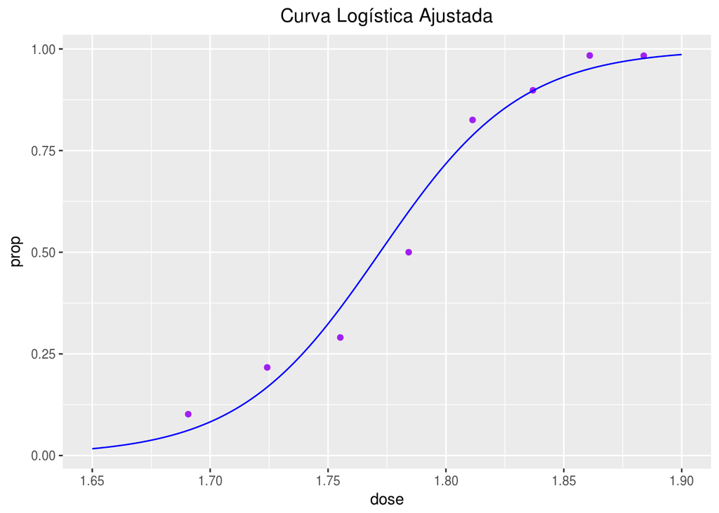

```r
# plot:
# criando um conjunto com varios nros entre 1.65 e 1.9
xx=1.65 +(0:250)/1000
predictors=coef(bee_logit_model)[1]+coef(bee_logit_model)[2]*xx

# probabilidades e proporções (para o plot)
prob=exp(predictors)/(1+exp(predictors))

prop <- beetles[,"killed"]/ beetles[,"total"]

# com ggplot2
library(ggplot2)
ggplot()+
  geom_point(aes(x=dose, y=prop), colour="purple")+
  geom_line(aes(x=xx, y=prob), colour="blue")+
  ggtitle( 'Curva Logística Ajustada' )+
  theme(plot.title = element_text(hjust=0.5))
```

```r
# ou com plotly:
library(magrittr)
# pontos e linhas no mesmo plot:
# https://plot.ly/r/line-and-scatter/
p <- plotly::plot_ly(x = ~dose, y = ~prop, name = 'prop', type = 'scatter', mode = 'markers') %>%
  plotly::add_trace(x= ~xx, y = ~prob, name = 'prob', mode = 'lines') %>%
  plotly::layout(title = "Curva Logística Ajustada")

p
```

[interactive chart not shown]

Testes para o parâmetro $\beta$:

```r
# testes para existência de regressão

# 1) razao de verossimilhanças
library(lmtest)
lrtest(bee_logit_model) # ok! os resultados batem e sao significativos (rejeita H0)
```

|  | #Df | LogLik | Df | Chisq | Pr(>Chisq) |
| --- | --- | --- | --- | --- | --- |
| 1 | 2 | -18.41052 | NA | NA | NA |
| 2 | 1 | -151.52785 | -1 | 266.2347 | 7.508746e-60 |

```r
# 2) teste de Wald
waldtest(bee_logit_model)
```

|  | Res.Df | Df | F | Pr(>F) |
| --- | --- | --- | --- | --- |
| 1 | 6 | NA | NA | NA |
| 2 | 7 | -1 | 138.3724 | 2.27897e-05 |

Uma vez que ambos os testes indicam que os $\beta$’s são significantes, há evidências da existência de regressão logística entre a morte de abelhas e a dosagem do produto utilizado.

Intervalos de Confiança:

```r
# IC
# summary(bee_logit_model)
# IC_B <- bee_logit_model$coefficients[2] + c(-1,1)*qnorm(0.975)*2.8939

# ou
confint.default(bee_logit_model)
```

```
##                 2.5 %    97.5 %
## (Intercept) -69.09124 -49.28385
## dose         27.83553  38.96588
```

### Referências Bibliográficas

AGRESTI, ALAN. *An Introduction to Categorical Data Analysis*. John Wiley & Sons, second edition, 2007.

NOTAS DE AULA. *Análise de Dados Categorizados*. Curso de Graduação em Estatística, UnB, 2018.

R CORE TEAM. *R: A language and environment for statistical computing*. R Foundation for Statistical Computing, Vienna, Austria. URL https://www.R-project.org/.